# Chapter 3: Model Now!

Estimate Losses

Simon Thornewill von Essen

14 2 2020

How do we measure the impact of an effect that occurs some amount of the time?

1. We define list of risks
2. We define a timescale where it might happen
3. We assign a prob of occuring
4. We create a 90% CI for losses
5. Get CI from multiple expers where possible

We can then use these stats to calculate the impact.

Say, we have events A-D with the following probabilities

```r
P_n <- c(0.1, 0.05, 0.01, 0.03)
```

We can generate a monte carlo simulation whether these events happen.

```r
as.numeric(runif(1) < P_n)
```

```
## [1] 0 0 0 0
```

Next, we want to define our lower and upper bounds

```r
UB_n <- c(5e5, 1e7, 2.5e7, 1.5e7)
LB_n <- c(5e4, 1e5, 2e5, 1e5)
```

From the upper and lower bounds, we can calculate our parameters for normal distributions

```r
E_lnX_n <- (log(UB_n) + log(LB_n))/2
Std_lnX_n <- (log(UB_n) - log(LB_n))/3.29  # How did we get the 3.29 number?
```

Apparently you can infer the standard deviation from a confidene interval (given you know to what level of confidence it is) estimating. The number that we divide the difference of the two bounds by is equal to the following equation

```r
get_std <- function(n, UB, LB, alpha){
  df <- n-1
  (sqrt(n) * (UB - LB)) / (2 * qt(1-alpha/2, df))  # Note that you need to divide alpha by two to get the two-tail
}

get_std(19, 7.54, 6.36, 0.05)
```

```
## [1] 1.224106
```

What the author does is something much simpler. Instead, he assumes the sample size is 1 and uses a Z statistic instead of a t statistic.

$$s^2 \approx \frac{\sqrt{n}(\textrm{UB}-\textrm{LB})}{2*Z_{\textrm{alpha, tail}}}, n=1, tail=2$$

There is an implementation below.

```r
alpha <- 0.10
tails <- 2
2 * qnorm((1-(alpha/tails)), 0, 1)
```

```
## [1] 3.289707
```

Using this method, the standard deviation calculated by my example using a t statistic is as follows

```r
(7.54 - 6.36) / (2 * qnorm(1-0.05/2, 0, 1))
```

```
## [1] 0.3010259
```

We can see that the severely underestimate the standard deviation, so it might be worth using the calculating involving the t statistic instead of the z statistic.

```r
(log(UB_n) - log(LB_n)) / (2 * qt(1-0.1/2, 1))
```

```
## [1] 0.1823468 0.3646937 0.3823649 0.3968033
```

```r
Std_lnX_n
```

```
## [1] 0.6998739 1.3997478 1.4675726 1.5229895
```

Anyway! Using these parameters, we can simulate the possible loss of an event

```r
loss <- rep(0, 4)

for(i in 1:length(loss)){

  # Say for the sake of example
  # randn <- runif(1)
  randn <- 0.025

  if(randn < P_n[i]){
    loss[i] <- qlnorm(randn, E_lnX_n[i], Std_lnX_n[i])
  }
}

loss
```

```
## [1] 40108.49 64347.63     0.00 61897.72
```

So, when an event occurs, we can now estimate our losses from it.

```r
est_loss <- sum(loss)

est_loss
```

```
## [1] 166353.8
```

We can now simulate this many times and get a distribution

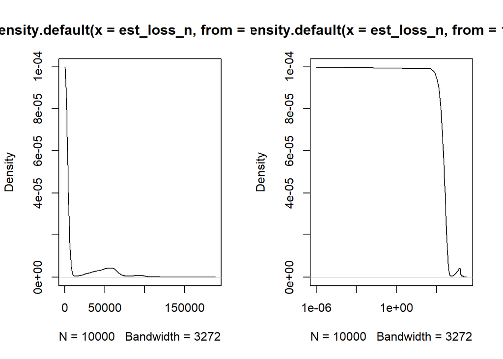

```r
n.iter <- 1e4

est_loss_n <- rep(0, n.iter)

for(j in 1:n.iter){
  loss <- rep(0, 4)
  for(i in 1:length(loss)){
    randn <- runif(1)
    if(randn < P_n[i]){
      loss[i] <- qlnorm(randn, E_lnX_n[i], Std_lnX_n[i])
    }
  }
  est_loss_n[j] <- sum(loss)
}

par(mfrow=c(1, 2))
plot(density(est_loss_n, from=0.000001))
plot(density(est_loss_n, from=0.000001), log='x')
```

We can obviously make this analysis more complex, but this is an interesting start.